# 1 Introduction

- country borders (polygon geometries)
- world rivers (line geometries)
- the locations of ports (point geometries)

All these maps, whose main purpose is to show the *locations* of features, are called “reference” maps.

But when we build maps in epidemiology (and in most other fields) what we really care about is not the locations themselves, but how specific attributes vary across these locations. For example: we might make maps to show:

- the incidence of a disease across different countries;
- the concentration of a microbe/chemical in different rivers;
- how many travelers transit annually through different ports.

Such maps, which aim to show the spatial variability of an attribute, are called *thematic* maps. These thematic maps usually use reference maps as their base, but they then add color or size variation to the base geometries in order to convey qualitative or quantiative information about specific themes or attributes.

# 2 Packages

```r
# Load packages
if(!require(pacman)) install.packages("pacman")
pacman::p_load(rnaturalearth,
               sf,
               here,
               tidyverse,
               ggspatial)
```

# 3 Thematic maps with Point geometries

## 3.1 Qualitative

```r
airports <- ne_download(scale = 10,
                        type = "airports",
                        returnclass = "sf")
```

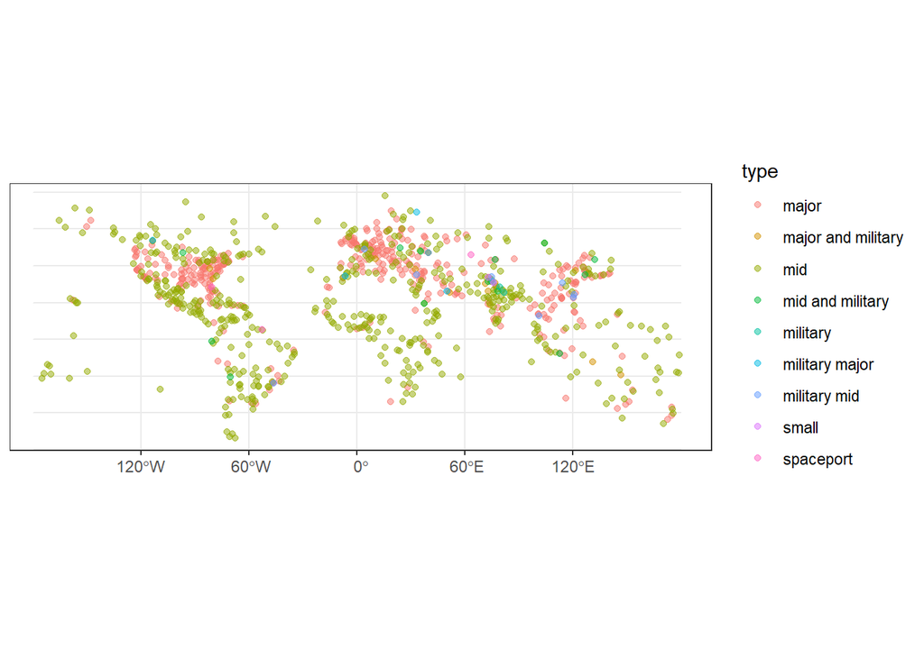

```r
ggplot(data = airports) +
  geom_sf(aes(color = type), alpha = 0.5)
```

## 3.2 Quantitative

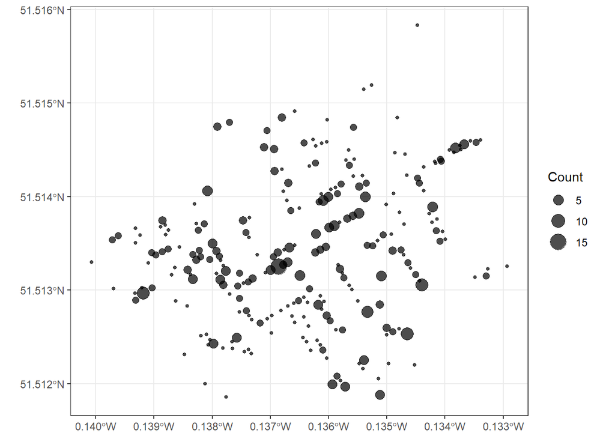

```r
cholera_deaths <- read_rds(here("ch06_basic_geospatial_viz/data/cholera_deaths.rds"))

ggplot(data = cholera_deaths) +
  geom_sf(mapping = aes(size = Count), alpha = 0.7)
```

Remember that under the hood, ggplot is passing the “geometry” column to the `geometry` argument. You can make this explicit with `aes(geometry = geometry)` . For example:

```r
ggplot(data = cholera_deaths) +
  geom_sf(mapping = aes(size = Count, geometry = geometry), alpha = 0.7)
```

# 4 Thematic maps with Line geometries

## 4.1 Qualitative

```r
roads <-
  ne_download(scale = 10,
                category = "cultural",
                type = "roads",
                returnclass = "sf")
```

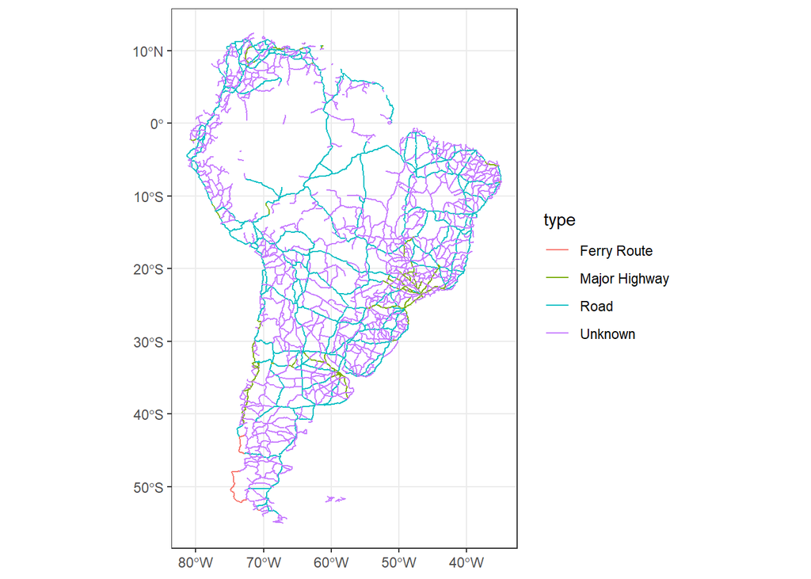

```r
south_am_roads <-
  roads %>%  # filter the dataset to reduce time needed to plot
  filter(continent == "South America")

ggplot(data = south_am_roads) +
  geom_sf(aes(color = type))
```

## 4.2 Quantitative

Below is an example with rivers in the Sacramento basin in California US. Data from here: https://zenodo.org/record/4985219.

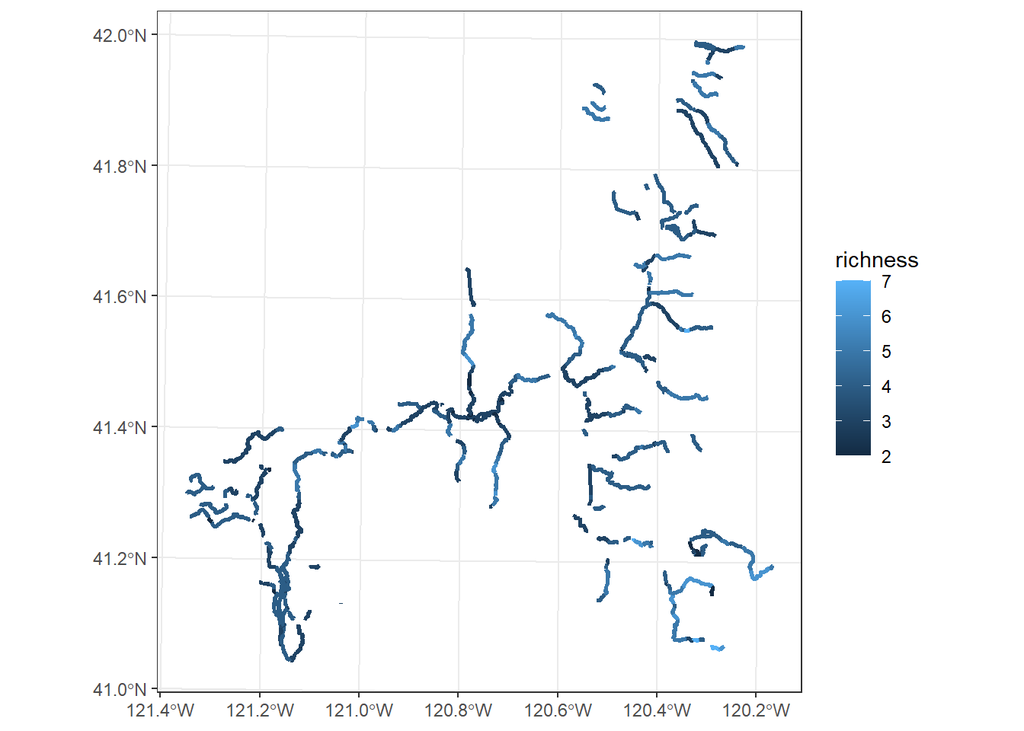

```r
sacramento_rivers <- read_rds(here("ch06_basic_geospatial_viz/data/sacramento_rivers.rds"))

sacramento_rivers %>%
  ggplot() +
  geom_sf(aes(color = richness), size = 1)
```

“Richness” is the estimated number of fish species in each segment of the river.

# 5 Thematic maps with Polygon geometries

## 5.1 Qualitative

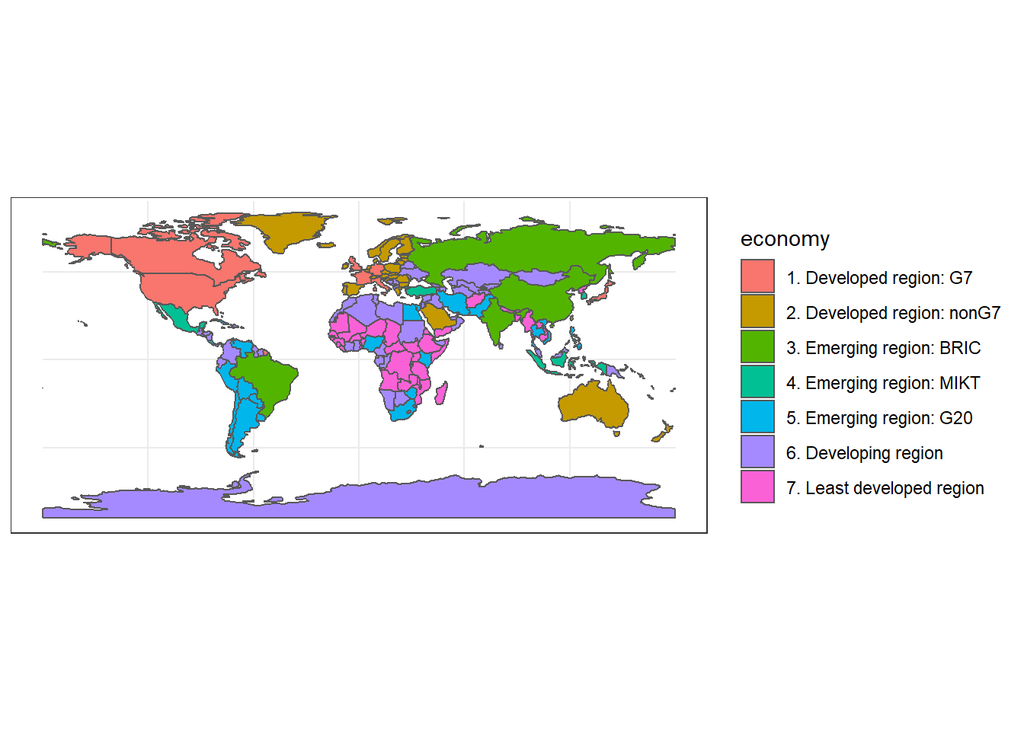

```r
countries <- ne_countries(returnclass = "sf")

ggplot(data = countries) +
  geom_sf(aes(fill = economy))
```

## 5.2 Quantitative

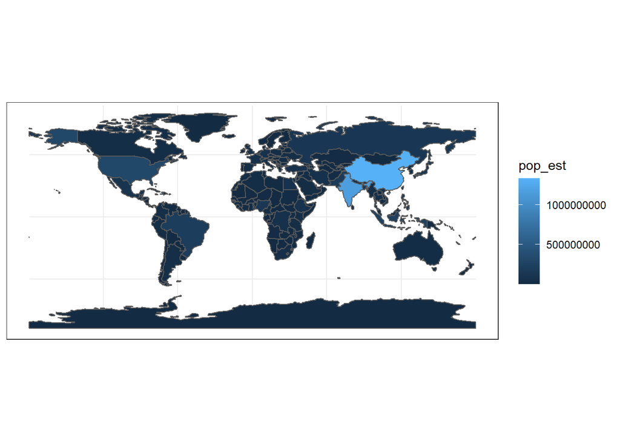

```r
ggplot(data = countries) +
  geom_sf(aes(fill = pop_est))
```

# 6 Multiple layers

So far we have been plotting single geometries.

This can be done by plotting multiple geometries:

E.g. for the map with world airports:

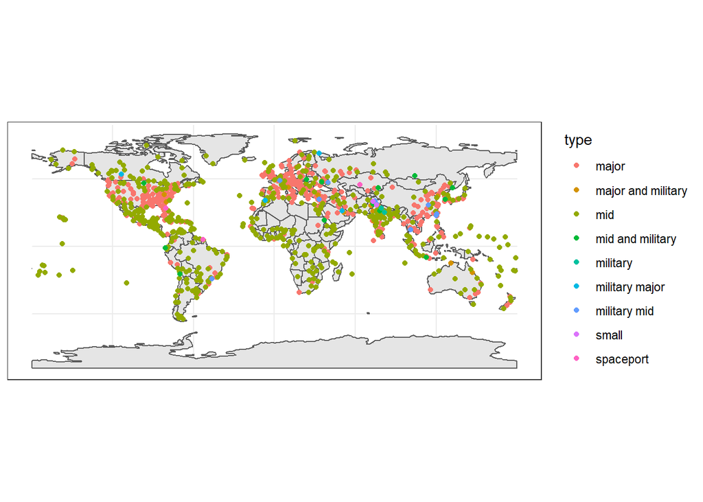

```r
ggplot() +
  geom_sf(data = countries) +
  geom_sf(data = airports, aes(color = type))
```

For the map of south american roads:

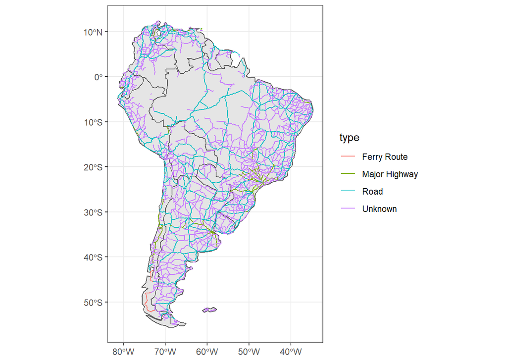

```r
south_am_countries <- countries %>% filter(continent == "South America")

ggplot() +
  geom_sf(data = south_am_countries) +
  geom_sf(data = south_am_roads, aes(color = type))
```

You could also add a “Google Maps-like” base map with streets and buildings….using the `annotation_map_tile()` function from ggspatial. For example, for the cholera deaths plot:

[figure not shown]

```r
ggplot(data = cholera_deaths) +
  annotation_map_tile(zoomin = 0) +
  geom_sf(mapping = aes(size = Count, geometry = geometry), alpha = 0.7)
```

# Contributors

The following team members contributed to this lesson:

- [KENE DAVID NWOSU](https://thegraphcourses.org/members/kendavidn/)  
  Data analyst, the GRAPH Network

  Passionate about education.
- [ANDREE VALLE CAMPOS](https://thegraphcourses.org/members/avallecam/)  
  R Developer and Instructor, The Graph Network

  Motivated by reproducible science and education.
- [LAURE VANCAUWENBERGHE](https://thegraphcourses.org/members/lolovanco)  
  Data analyst, the GRAPH Network

  A firm believer in science for good, striving to ally programming, health and education.

# References

Some material in this lesson was adapted from the following sources:

- *Batra, Neale, et al. (2021). The Epidemiologist R Handbook. Chapter 28: GIS Basics*. (2021). Retrieved 01 April 2022, from https://epirhandbook.com/en/gis-basics.html
- Moreno, Mel, and Mathieu Bastille. “Mel Moreno and Mathieu Basille.” Drawing beautiful maps programmatically with R, sf and ggplot2 — Part 1: Basics, October 25, 2018. https://r-spatial.org/r/2018/10/25/ggplot2-sf.html.
- *Lovelace, R., Nowosad, J., & Muenchow, J. Geocomputation with R. Chapter 2: Geographic data in R*. (2019). Retrieved 01 April 2022, from https://geocompr.robinlovelace.net/spatial-class.html
- *Moraga, Paula. Geospatial Health Data: Modeling and Visualization with R-INLA and Shiny. Chapter 2: Spatial data and R packages for mapping*. (2019). Retrieved 01 April 2022, from https://www.paulamoraga.com/book-geospatial/sec-spatialdataandCRS.html
- *Baumer, Benjamin S., Kaplan, Daniel TRUE., and Horton, Nicholas J. Modern Data Science with R. Chapter 17: Working with geospatial data*. (2021). Retrieved 05 June 2022, from https://mdsr-book.github.io/mdsr2e/ch-spatial.html

This work is licensed under the [Creative Commons Attribution Share Alike](https://creativecommons.org/licenses/by-sa/4.0/) license.